# hw5

## 使用packages

```r
library(e1071)
library(ggplot2)
library(stats)
library(jpeg)
```

## 使用資料

本次作業使用basketball-reference所記錄之NBA2017-18賽季球隊進階數據，並且擷取了東區15支球隊於2017/11/17前的所有比賽，共212場比賽數據及21個變數。

NBA Reference：https://www.basketball-reference.com/

```r
nba <- read.csv("hw5data.csv")
#查看資料長相
head(nba)
```

```
##   Team home Opp W.L  Tm Opp.1  ORtg  DRtg Pace   FTr X3PAr   TS. TRB. AST.
## 1  BOS    1 CLE   0  99   102  99.7 102.7 99.3 0.284 0.364 0.500 47.9 66.7
## 2  BOS    0 MIL   0 100   108 102.2 110.4 97.9 0.231 0.308 0.499 48.9 59.0
## 3  BOS    1 PHI   1 102    92 102.5  92.4 99.5 0.381 0.345 0.520 53.9 45.7
## 4  BOS    0 NYK   1 110    89 116.4  94.2 94.5 0.360 0.387 0.633 48.8 70.3
## 5  BOS    1 MIL   1  96    89  99.9  92.6 96.1 0.282 0.385 0.547 54.9 63.6
## 6  BOS    1 MIA   1  96    90 102.4  96.0 93.7 0.321 0.284 0.519 50.6 44.1
##   STL. BLK.  eFG. TOV. ORB. FT.FGA btob
## 1 11.1  6.6 0.455  9.2 18.0  0.216    0
## 2 12.3  3.6 0.489 10.7 22.0  0.121    1
## 3  4.0  8.3 0.476 16.2 29.8  0.262    0
## 4 11.6  9.6 0.587 12.1 13.5  0.293    0
## 5  7.3  7.7 0.494 14.6 14.6  0.244    0
## 6 11.7 10.4 0.457 11.5 24.4  0.272    0
```

```r
#觀察資料維度
dim(nba)
```

```
## [1] 212  21
```

```r
#各隊進行的比賽數
table(nba$Team)
```

```
##
## ATL BOS BRK CHI CHO CLE DET IND MIA MIL NYK ORL PHI TOR WAS
##  15  15  14  12  13  15  14  15  14  14  14  15  14  14  14
```

## 將比賽分群

我將資料中所有的比賽分為3群，希望能藉由kmeans法所分出的比賽群集進一步挖掘資料中有趣的現象。

我將分群結果的場次勝負分平均加以計算後，可以看出群一代表大部分贏球的比賽，群二則是代表大部分輸球的比賽，群三由勝負分來看沒那麼容易區分，或許有其他變數決定了這些比賽場次的分群。

```r
kk <- nba[,c(2,7:21)]
set.seed(34)
kmeansOut <- kmeans(kk, 3, nstart = 50)
nba$cluster <- kmeansOut$cluster
nba$winloss <- nba$Tm - nba$Opp.1
#各群的勝負分數平均
tapply(nba$winloss,nba$cluster,mean)
```

```
##           1           2           3
##  11.2236842 -13.1692308   0.4507042
```

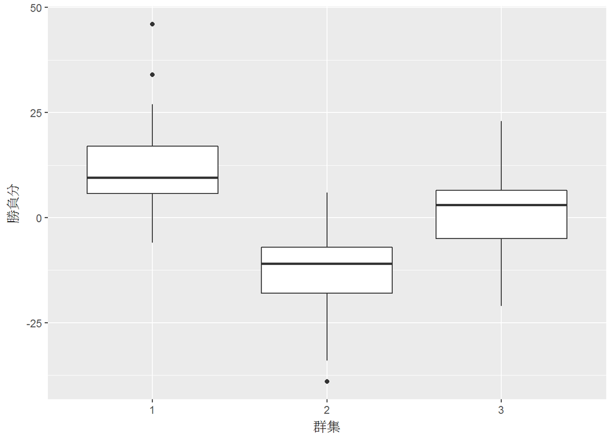

```r
#各群勝負分分布圖
ggplot(nba,aes(x=as.factor(cluster),y=winloss))+geom_boxplot()+labs(x='群集',y='勝負分')
```

## ANOVA分析

這裡我抓了兩個變數進行ANOVA分析，判斷由kmeans分出的群集當中這些變數是否有差異。

首先抓出Pace，也就是比賽的節奏。從p-value=0.847不拒絕H0的結果，推論比賽節奏的快慢並不是贏球或輸球的保證，可能有球隊打快節奏仍然常敗，習慣慢節奏的球隊仍有自己的取勝之道。

接著我抓取TRB%，也就是籃板率。從極小的p-value推論不同群間的籃板率有顯著差異，並且勝分高的比賽普遍有著較高的籃板率，輸球的比賽籃板率亦相對較低，因此驗證了灌籃高手當中，赤木隊長的經典名言：「掌握籃板球的人，便能夠主宰比賽！」

```r
#檢驗每群的pace是否相同
anova(m1 <- lm(cluster~Pace,data=nba))
```

```
## Analysis of Variance Table
##
## Response: cluster
##            Df  Sum Sq Mean Sq F value Pr(>F)
## Pace        1   0.026 0.02609  0.0373  0.847
## Residuals 210 146.856 0.69931
```

```r
#檢驗每群的籃板率是否相同
anova(m1 <- lm(cluster~TRB.,data=nba))
```

```
## Analysis of Variance Table
##
## Response: cluster
##            Df  Sum Sq Mean Sq F value   Pr(>F)
## TRB.        1   5.707  5.7071  8.4894 0.003959 **
## Residuals 210 141.175  0.6723
## ---
## Signif. codes:  0 '***' 0.001 '**' 0.01 '*' 0.05 '.' 0.1 ' ' 1
```

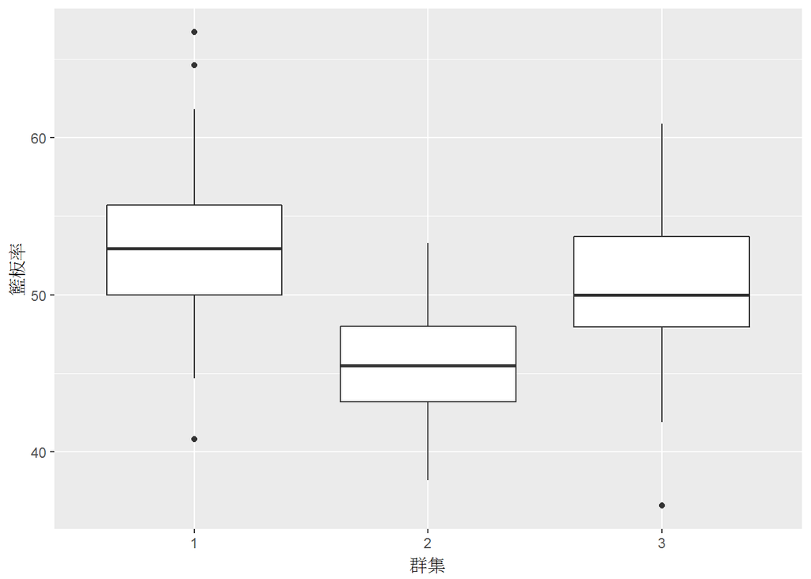

[figure not shown]

```r
ggplot(nba,aes(x=as.factor(cluster),y=TRB.))+geom_boxplot()+labs(x='群集',y='籃板率')
```

## 相關矩陣

進一步地，我建立所有變數的相關矩陣，希望能找出各變數的關聯。

```r
cor(nba[,c(2,4,7:21)])
```

```
##                 home         W.L        ORtg        DRtg        Pace
## home    1.0000000000 -0.14411401 -0.08599612  0.05700409  0.06496680
## W.L    -0.1441140110  1.00000000  0.50950547 -0.49192883 -0.06419789
## ORtg   -0.0859961241  0.50950547  1.00000000  0.24789098 -0.06828279
## DRtg    0.0570040912 -0.49192883  0.24789098  1.00000000  0.01636178
## Pace    0.0649668028 -0.06419789 -0.06828279  0.01636178  1.00000000
## FTr    -0.0095972774  0.16320737  0.11428123  0.03248178  0.25063939
## X3PAr   0.0322678804 -0.04965557  0.01912462 -0.04424711 -0.07252890
## TS.    -0.0139860054  0.44818763  0.86140190  0.19490245 -0.01200980
## TRB.   -0.0905666503  0.54162906  0.40229659 -0.35028246 -0.07087659
## AST.    0.0447419970  0.02224883  0.05653580 -0.05137673 -0.06581930
## STL.    0.1196885706  0.14375382  0.03903943 -0.17782101 -0.06159778
## BLK.   -0.2075757244  0.17527943  0.03856410 -0.14571468  0.03101238
## eFG.   -0.0221204667  0.40235378  0.81841800  0.18188536 -0.03757162
## TOV.    0.1405207753 -0.07176524 -0.19390137 -0.11600480  0.04029083
## ORB.   -0.0858760737  0.28507403  0.42031931 -0.01103617 -0.10412203
## FT.FGA -0.0002376905  0.20356603  0.19099851  0.05532316  0.19359745
## btob    0.1110344098 -0.10327154 -0.06700393  0.13352992  0.01702874
##                 FTr        X3PAr         TS.        TRB.        AST.
## home   -0.009597277  0.032267880 -0.01398601 -0.09056665  0.04474200
## W.L     0.163207366 -0.049655574  0.44818763  0.54162906  0.02224883
## ORtg    0.114281233  0.019124624  0.86140190  0.40229659  0.05653580
## DRtg    0.032481776 -0.044247106  0.19490245 -0.35028246 -0.05137673
## Pace    0.250639388 -0.072528904 -0.01200980 -0.07087659 -0.06581930
## FTr     1.000000000 -0.071508438  0.13282696  0.05728196 -0.20902443
## X3PAr  -0.071508438  1.000000000  0.09120319 -0.01962886  0.37972625
## TS.     0.132826957  0.091203187  1.00000000  0.32120813  0.09817769
## TRB.    0.057281965 -0.019628855  0.32120813  1.00000000  0.02638939
## AST.   -0.209024427  0.379726249  0.09817769  0.02638939  1.00000000
## STL.   -0.123482253 -0.004446974  0.02523191 -0.07342416  0.13768464
## BLK.    0.067225606 -0.091998401  0.01789936  0.12892810 -0.06255953
## eFG.   -0.064833120  0.081256504  0.95967827  0.31249101  0.15403386
## TOV.    0.006439197  0.185543394  0.18985883  0.16708322  0.08047369
## ORB.    0.004290680 -0.049765425  0.12411873  0.64701853 -0.02198255
## FT.FGA  0.938023554 -0.019087282  0.20672446  0.06075201 -0.20968733
## btob   -0.050526162 -0.038813660 -0.03226728 -0.07574530 -0.04304214
##                STL.        BLK.        eFG.         TOV.        ORB.
## home    0.119688571 -0.20757572 -0.02212047  0.140520775 -0.08587607
## W.L     0.143753817  0.17527943  0.40235378 -0.071765237  0.28507403
## ORtg    0.039039429  0.03856410  0.81841800 -0.193901372  0.42031931
```

[output cut: 17 more lines]

```
## ORtg    0.1909985144 -0.06700393
## DRtg    0.0553231596  0.13352992
## Pace    0.1935974512  0.01702874
## FTr     0.9380235537 -0.05052616
## X3PAr  -0.0190872815 -0.03881366
## TS.     0.2067244585 -0.03226728
## TRB.    0.0607520075 -0.07574530
## AST.   -0.2096873279 -0.04304214
## STL.   -0.0912917341  0.04421788
## BLK.    0.0289238930 -0.04559102
## eFG.   -0.0468697087 -0.03047918
## TOV.    0.0109473022  0.10111171
## ORB.    0.0285207901 -0.01340233
## FT.FGA  1.0000000000 -0.04036072
## btob   -0.0403607158  1.00000000
```

## 二維SVM

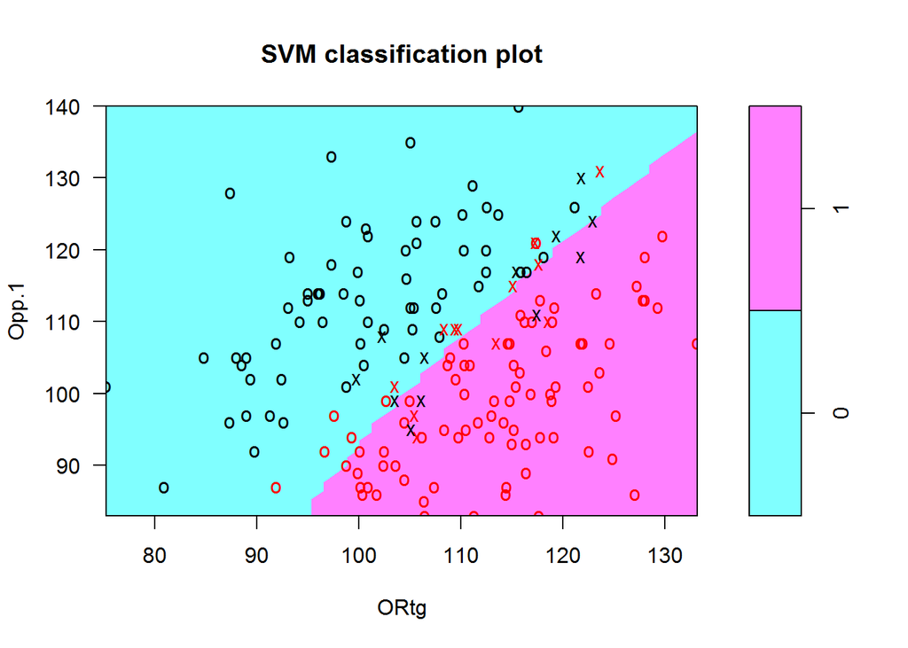

```r
traindata1 <- nba[1:170,c(4,6,7)]
testdata1 <- nba[171:212, c(6,7)]
svmfit = svm(as.factor(W.L) ~ ., data = traindata1,
             kernel = "polynomial",
             cost = 10, scale = FALSE)
#SVM分類圖
plot(svmfit, traindata1)
```

```r
predict1 = predict(svmfit, testdata1)
#正確度表格
ans1 = table(predict1, nba[171:212, 4])
print(ans1)
```

```
##
## predict1  0  1
##        0 25  4
##        1  3 10
```

```r
#此模型正確率
acc1 = (ans1[1,1]+ans1[2,2])/sum(ans1)
print(acc1)
```

```
## [1] 0.8333333
```

## 高維度的SVM

從以上結果可以得知模型精準度達0.833，已經是足夠精確的模型，接著繼續嘗試高維度的SVM，我將網站中截取到的所有進階數據代入模型中，得到了100%的精確度，由此可知這些進階數據已經能完美的詮釋比賽勝負，是能夠參考及解讀的數據。

```r
traindata2 <- nba[1:170,c(4,7:21)]
testdata2 <- nba[171:212, c(7:21)]
svmfit2 = svm(as.factor(W.L) ~ ., data = traindata2,
             kernel = "polynomial",
             cost = 10, scale = FALSE)
predict2 = predict(svmfit2, testdata2)
#正確度表格
ans2 = table(predict2, nba[171:212, 4])
print(ans2)
```

```
##
## predict2  0  1
##        0 28  0
##        1  0 14
```

```r
acc2 = (ans2[1,1]+ans2[2,2])/sum(ans2)
#此模型正確率
print(acc2)
```

```
## [1] 1
```